# The Rejection Factor

Development of a new bibliometric

Antoine Filipovic-Pierucci

2016-05-10

# Context

Litterature about measuring the quality of scientific publications is abundant, and the use of these metrics for individual assessement of academics is widespread. On the other hand few studies exist on the measurement and the evaluation of rejections.

This is a severe oversight, because most of the work of academics is actually rewarded by rejections. This assertion can be proven by the very content of journal rejection letters, that often state that an important proportion of submissions (usually set around 80-90%) are outright rejected.

Whether this threshold is arbitrary, whether it should be so if it actually is, or how it is set if it is not, is quite another problem.

> *The vast majority of manuscripts submitted to JAMA Psychiatry are of outstanding quality, yet we have to reject more than 85%.*

> *[…] our submission rate has gone up so much that we now have to reject 80-90 % of papers submitted.*

Some research has been made by scholars in the direction of rejection of rejection. While this approach may prove useful to increase the proportion of accepted manuscript, we think it may be made obsolete by a new and innovating approach: that of giving value to rejection itself.

Chapman Cath, Slade Tim. *Rejection of rejection: a novel approach to overcoming barriers to publication* BMJ 2015; 351 :h6326

The objective of this study was to compute a new metric, the *cumulative rejection factor*, to assess the level and the quality of rejected work for an academic.

# Definition

The *cumulative rejection factor* (CRF) for a given academic is defined as the sum of the *rejection factors* (RF) of the journals were the academic was rejected during a defined time period. The *rejection factor* of a journal is defined as the inverse of the journal impact factor.

e.g. one year.

$$RF = \frac{1}{IF}$$

For an academic who got rejected from $n$ journals:

$$CRF = \sum_{i=1}^{n}{RF_{i}}$$

Where $RF_{i}$ is the *rejection factor* for the $i^{th}$ journal.

Using data from *SCImago Journal & Country Rank* it is possible to compute RF for most scientific journals.

Available on the internet: http://www.scimagojr.com/journalrank.php

English-speaking journals, highest RF.

| Journal | RF |
| --- | --- |
| International Journal of Business Research | 100 |
| Philosophy and Literature | 100 |
| Fourth Genre: Explorations in Nonfiction | 100 |
| English Studies in Canada | 100 |
| EMS Insider | 100 |
| Environmental Law and Management | 100 |
| MD advisor : a journal for New Jersey medical community | 100 |
| English Language Notes | 100 |
| Transactions - Society of Naval Architects and Marine Engineers | 100 |
| American Scholar | 100 |

English-speaking journals, lowest RF.

| Journal | RF |
| --- | --- |
| Ca-A Cancer Journal for Clinicians | 0.013 |
| Chemical Reviews | 0.022 |
| Nature Reviews Cancer | 0.028 |
| Nature Reviews Immunology | 0.028 |
| Nature Reviews Genetics | 0.029 |
| Nature Reviews Molecular Cell Biology | 0.029 |
| Chemical Society Reviews | 0.030 |
| Progress in Materials Science | 0.034 |
| Annual Review of Biochemistry | 0.034 |
| Lancet, The | 0.035 |

# Rationale

The rationale for using journal-specific weights (*rejection factors*) instead of simply counting rejections is the following: the metric should take into account that different journals have different probabilities of rejection.

A *reductio ad absurdum* example would be: it is much more difficult to be rejected from a low IF journal than from *Science* or *The Lancet*. This difficulty should be reflected in the metric by giving more points to rejections from low IF journals. This is why the RF is calculted as the inverse of the IF.

Or from the *Journal of Universal Rejection*, http://www.universalrejection.org/

# Use case

The use of CRF can be illustrated by a completely fictional example. Three academics, Alicia, Antoine and Chloé, are assessed by their respective CRF. They got rejected from the following journals:

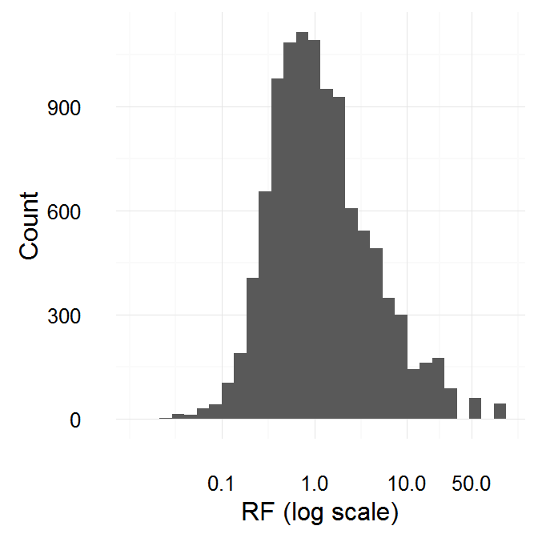

Histogram of RF for english-speaking journals.

| Academic | Rejections (current year) | RF |
| --- | --- | --- |
| Alicia | Pediatrics | 0.181 |
| Alicia | Value in Health | 0.336 |
| Alicia | British Medical Journal | 0.186 |
| - | - | - |
| Antoine | Transactions of the Royal Society of TMH | 0.526 |
| Antoine | European Journal of Public Health | 0.415 |
| Antoine | British Journal of Psychiatry | 0.180 |
| Antoine | JAMA Psychiatry | 0.082 |
| Antoine | European Journal of Epidemiology | 0.191 |
| Antoine | International Journal of Epidemiology | 0.139 |
| Antoine | Social Psychiatry and Psychiatric Epidemiology | 0.395 |
| - | - | - |
| Chloé | BMJ Quality and Safety | 0.275 |
| Chloé | British Medical Journal | 0.186 |

From these data it can be seen that while Alicia and Chloé submit in journals with similar RF, Alicia had more success in getting rejections, thus yielding a higher CRF. Antoine got more rejections, furthermore in journals where rejections were more difficult, yielding a much higher CRF.

| Academic | CRF | Average RF by journal |
| --- | --- | --- |
| Alicia | 0.703 | 0.234 |
| Antoine | 1.926 | 0.275 |
| Chloé | 0.461 | 0.230 |

# Possible improvements

The RF could be standardized by study domain. By using the same metric for all domains the CRF of academics working in low-impact fields (e.g. fourth genre explorers in nonfiction) is artificially inflated.

Which is a problem if rejection is easy in these domains for journals with comparatively higher RF. This hypothesis is far from certain.

Some journals are known to accept any submission, regardless of the quality of the research. This is especially true for so-called predatory journals, whose business model relies solely on publishing as many studies as possible. Since it is theoretically impossible to be rejected, any rejection from these journals should be highly rewarded.

See Jeffrey Beall’s work on the subject: https://scholarlyoa.com